# Customer Churn Analysis

Aadrika Singh

November 8, 2017

## WHAT IS CUSTOMER CHURN?

Customer churn refers to customers stopping the use of a service, switching to a competitor service, switching to a lower-tier experience in the service or reducing engagement with the service.

With easy communication and a number of service providers available in the telecommunication industry, almost everyone today has a telecom subscription. Churn is especially important to telecom service providers because it is easy for a subscriber to switch services.

Factors such as perceived frequent service disruptions, poor customer service experiences, and better offers from other competing carriers may cause a customer to churn (likely to leave).

## WHY IS CUSTOMER CHURN IMPORTANT FOR TELECOM INDUSTRIES?

Reducing customer churn is a key business goal of every telecom business. The ability to predict that a particular customer is at a high risk of churning, while there is still time to do something about it, represents a huge additional potential revenue source for every telecom business.

Besides the direct loss of revenue that results from a customer abandoning the business, the costs of initially acquiring that customer may not have already been covered by the customer’s spending to date. (In other words, acquiring that customer may have actually been a losing investment.)

Furthermore, it is always more difficult and expensive to acquire a new customer than it is to retain a current paying customer.

## HOW TO REDUCE CUSTOMER CHURN?

In order to succeed at retaining customers who would otherwise abandon the business, marketers and retention, experts must be able to :

- predict in advance which customers are going to churn through churn analysis, and
- know which marketing actions will have the greatest retention impact on each particular customer.

Armed with this knowledge, a large proportion of customer churn can be eliminated.

## HOW DOES PREDICTING CUSTOMER CHURN HELP?

Churn Prediction model can help analyze the historical data available with the business to find the list of customers which are at high risk to churn. This will help the telecom industry to focus on a specific group rather than using retention strategies on every customer.

Individualized customer retention is difficult because businesses usually have a big customer base and cannot afford to spend much time and money for it. However, if we could predict in advance which customers are at risk of leaving, we can reduce customer retention efforts by directing them solely toward such customers.

## CUSTOMER CHURN ANALYSIS

The project will aim to analyze the data for a telecommunication company (intended client for the project), and predict in advance, which customers are likely to churn, based on the data analysis.

The goals of the analysis:

- *acquire* a telecom company’s dataset
- perform *data wrangling* : clean the dataset and get it into a format amenable for analysis
- perform *exploratory data analysis* : summarize and visualize important characteristics and statistical properties of the dataset
- apply *machine learning* : in-depth data analysis, build models that predict the propensity of customers to churn, evaluate the results of models, and eventually, choose the best suitable predictive model to predict customers who may churn

*P.S. : The complete R code for this analysis can be found [here](https://github.com/singhaadrika/Customer-Churn/blob/master/Customer%20Churn%20Analysis.Rmd)*

## DATASET ACQUISITION

The dataset belongs to one of the sample datasets available in the IBM Watson Analytics community and can be obtained from [here](https://community.watsonanalytics.com/wp-content/uploads/2015/03/WA_Fn-UseC_-Telco-Customer-Churn.csv?cm_mc_uid=83066238020615050520398&cm_mc_sid_50200000=1510468770&cm_mc_sid_52640000=1510468770)

### DATASET DESCRIPTION

From the dataset description, we know that the dataset includes information about:

- Customers who left within the last month : the column is called Churn
- Services that each customer has signed up for : phone, multiple lines, internet, online security, online backup, device protection, tech support, and streaming TV and movies
- Customer account information : how long they’ve been a customer, contract, payment method, paperless billing, monthly charges, and total charges
- Demographic info about customers : gender, age range, and if they have partners and dependents

For analysis with R, the telecom company’s training dataset is imported as a data frame. Looking at the structure of the dataset :

```
## 'data.frame':    7043 obs. of  21 variables:
##  $ customerID      : Factor w/ 7043 levels "0002-ORFBO","0003-MKNFE",..: 5376 3963 2565 5536 6512 6552 1003 4771 5605 4535 ...
##  $ gender          : Factor w/ 2 levels "Female","Male": 1 2 2 2 1 1 2 1 1 2 ...
##  $ SeniorCitizen   : int  0 0 0 0 0 0 0 0 0 0 ...
##  $ Partner         : Factor w/ 2 levels "No","Yes": 2 1 1 1 1 1 1 1 2 1 ...
##  $ Dependents      : Factor w/ 2 levels "No","Yes": 1 1 1 1 1 1 2 1 1 2 ...
##  $ tenure          : int  1 34 2 45 2 8 22 10 28 62 ...
##  $ PhoneService    : Factor w/ 2 levels "No","Yes": 1 2 2 1 2 2 2 1 2 2 ...
##  $ MultipleLines   : Factor w/ 3 levels "No","No phone service",..: 2 1 1 2 1 3 3 2 3 1 ...
##  $ InternetService : Factor w/ 3 levels "DSL","Fiber optic",..: 1 1 1 1 2 2 2 1 2 1 ...
##  $ OnlineSecurity  : Factor w/ 3 levels "No","No internet service",..: 1 3 3 3 1 1 1 3 1 3 ...
##  $ OnlineBackup    : Factor w/ 3 levels "No","No internet service",..: 3 1 3 1 1 1 3 1 1 3 ...
##  $ DeviceProtection: Factor w/ 3 levels "No","No internet service",..: 1 3 1 3 1 3 1 1 3 1 ...
##  $ TechSupport     : Factor w/ 3 levels "No","No internet service",..: 1 1 1 3 1 1 1 1 3 1 ...
##  $ StreamingTV     : Factor w/ 3 levels "No","No internet service",..: 1 1 1 1 1 3 3 1 3 1 ...
##  $ StreamingMovies : Factor w/ 3 levels "No","No internet service",..: 1 1 1 1 1 3 1 1 3 1 ...
##  $ Contract        : Factor w/ 3 levels "Month-to-month",..: 1 2 1 2 1 1 1 1 1 2 ...
##  $ PaperlessBilling: Factor w/ 2 levels "No","Yes": 2 1 2 1 2 2 2 1 2 1 ...
##  $ PaymentMethod   : Factor w/ 4 levels "Bank transfer (automatic)",..: 3 4 4 1 3 3 2 4 3 1 ...
##  $ MonthlyCharges  : num  29.9 57 53.9 42.3 70.7 ...
##  $ TotalCharges    : num  29.9 1889.5 108.2 1840.8 151.7 ...
##  $ Churn           : Factor w/ 2 levels "No","Yes": 1 1 2 1 2 2 1 1 2 1 ...
```

Looking at the first 6 rows of the columns:

```
##   customerID gender SeniorCitizen Partner Dependents tenure PhoneService
## 1 7590-VHVEG Female             0     Yes         No      1           No
## 2 5575-GNVDE   Male             0      No         No     34          Yes
## 3 3668-QPYBK   Male             0      No         No      2          Yes
## 4 7795-CFOCW   Male             0      No         No     45           No
## 5 9237-HQITU Female             0      No         No      2          Yes
## 6 9305-CDSKC Female             0      No         No      8          Yes
##      MultipleLines InternetService OnlineSecurity OnlineBackup
## 1 No phone service             DSL             No          Yes
## 2               No             DSL            Yes           No
## 3               No             DSL            Yes          Yes
## 4 No phone service             DSL            Yes           No
## 5               No     Fiber optic             No           No
## 6              Yes     Fiber optic             No           No
##   DeviceProtection TechSupport StreamingTV StreamingMovies       Contract
```

[output cut: 20 more lines]

**Observation**: There are **7043** observations of **21** variables in the dataset, from which selected input features will be used to predict the outcome variable **churn**.

## DATA WRANGLING

The first step in analyzing data is to clean the dataset and get it into a format amenable for analysis.

**Action**: Based on the observations from above, we convert CustomerID and SeniorCitizen fields, to appropriate data types. Also, we list out how many missing values each column in the dataset has:

```
##       customerID           gender    SeniorCitizen          Partner
##                0                0                0                0
##       Dependents           tenure     PhoneService    MultipleLines
##                0                0                0                0
##  InternetService   OnlineSecurity     OnlineBackup DeviceProtection
##                0                0                0                0
##      TechSupport      StreamingTV  StreamingMovies         Contract
##                0                0                0                0
## PaperlessBilling    PaymentMethod   MonthlyCharges     TotalCharges
##                0                0                0               11
##            Churn
##                0
```

**Observation**: It is observed that only **TotalCharge** column has **11** missing values.

**Action**:

Analyze these missing values in a deeper sense, and find the rows that have missing values for TotalCharge:

```
##  [1]  489  754  937 1083 1341 3332 3827 4381 5219 6671 6755
```

Find the tenure for these customers:

```
##  [1] 0 0 0 0 0 0 0 0 0 0 0
```

Find the TotalCharge for customers with 0 as tenure:

```
##  [1] NA NA NA NA NA NA NA NA NA NA NA
```

**Observation**: Thus, it is observed that **all** the customers with **0 tenure period** have **missing TotalCharge** values.

**Action**: Thus, the NA values for TotalCharge will be replaced by 0, and it’s ensured that no columns have missing values anymore. Listing out the columns that might have missing values:

```
## character(0)
```

**Observation**: All the missing observations have been substituted and the data is now suitable for further analysis.

## EXPLORATORY DATA ANALYSIS

The next step in data analysis, which follows data wrangling, is exploratory data analysis, which refers to summarizing and visualizing important characteristics and statistical properties of the dataset.

Observing the distribution of customers between the classes *churned* and *not churned* :

### Distribution of people who churned

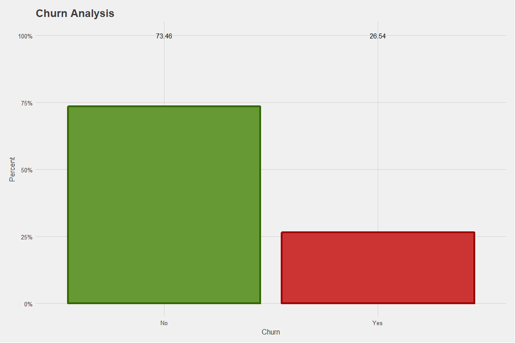

**Observation**: As observed from the histogram, the percentage of people churning is much lower than the percentage of people not churning. This also implies, that the dataset is highly imbalanced.

### Relationship between whether the customer has dependents and whether the customer churned or not

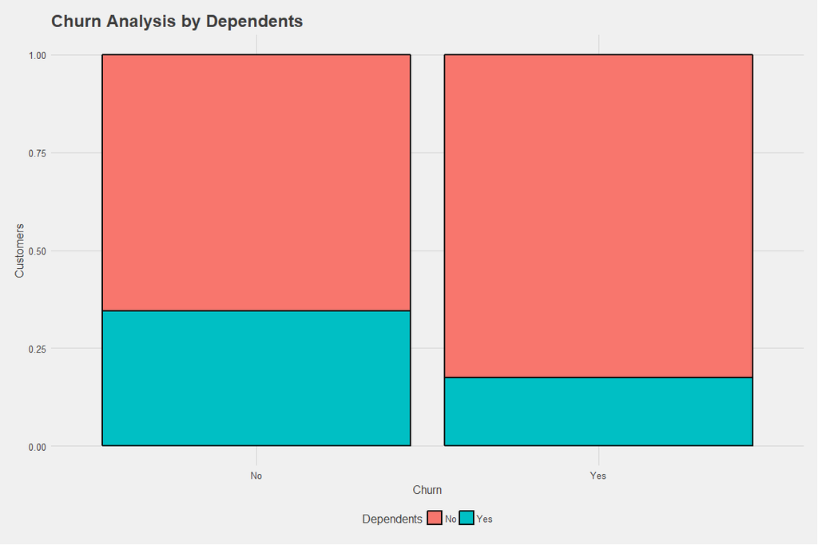

**Observation**: From the above bar chart, it can be inferred that, given a customer churns, it is most likely that the customer doesn’t have dependents.

### Relationship between payment method used by the customer and whether the customer churned or not

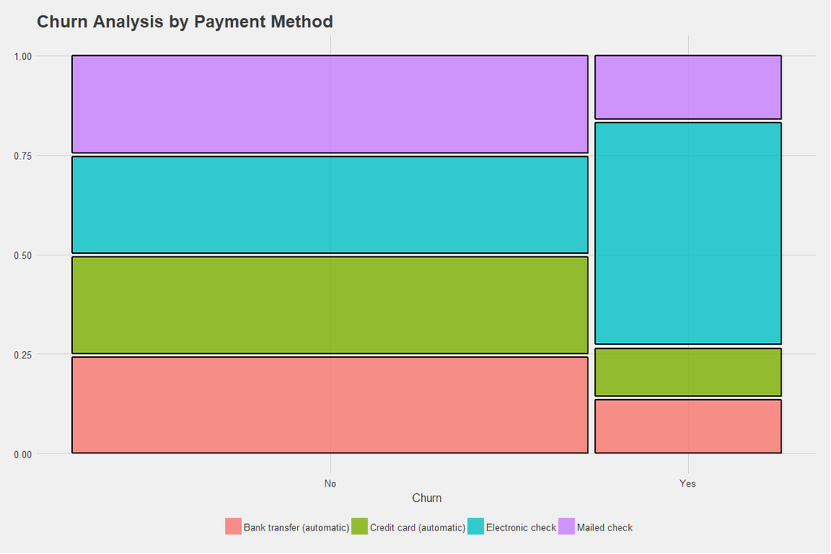

**Observation**: From the above mosaic plot, it can be inferred that, given a customer churns, it is most likely that the customer used **electronic check** as a method of payment.This could imply that the process of payment using electronic check may not be as convenient as other payment methods, and may need to be improved.

### Relationship between tenure (in months) and whether the customer churned or not

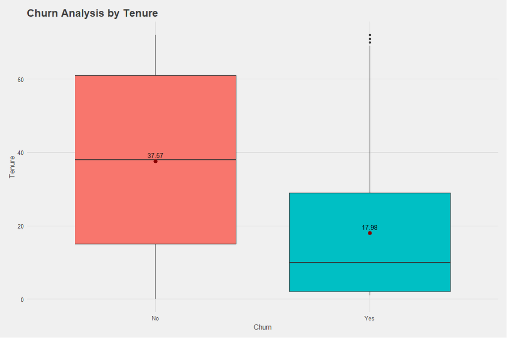

**Observation**: From the above boxplot, it can be inferred that, the average tenure period of customers who churn is much lower(almost half) than the average tenure period of customers who don’t churn. This could imply that most of the customers who churn are new customers, with an average tenure period of 18 months. However, there are a few outliers, where the customers churned, inspite of a longer tenure period (more than 60 months).

### Relationship between type of contract the customer has and whether the customer churned or not

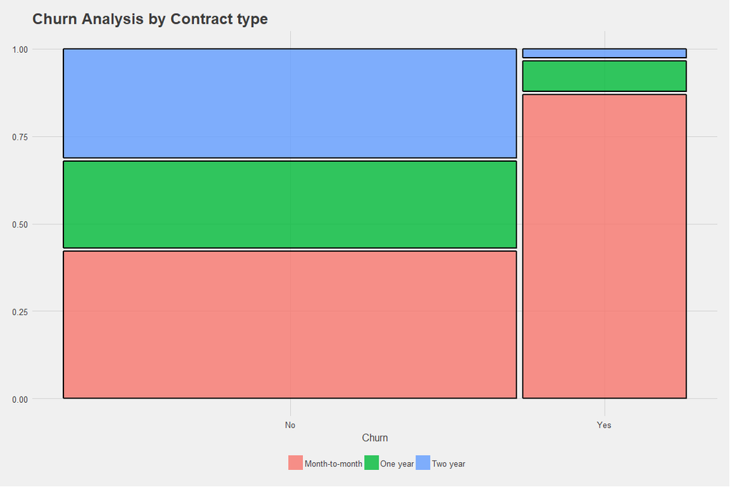

**Observation**: From the above mosaic plot, it can be inferred that, given a customer churns, it is most likely that the customer was tied with the company on a *month-to-month* based contract. This is expected, as it is easier for a customer to churn if he/she is not tied with a long term contract. Thus, the customers tied via a two year contract churn the least, followed by customers with one-year contract, and eventually followed by month-to-month contracts.

### Relationship between whether the customers used paperless billing and whether the customer churned or not

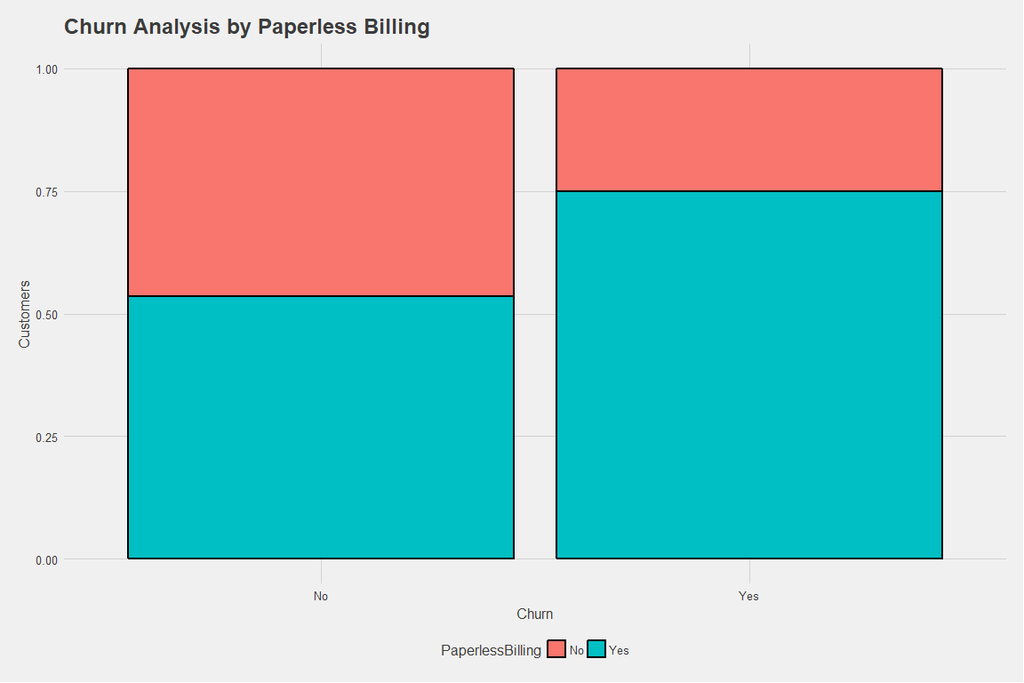

**Observation**: From the above bar chart, it can be inferred that, given a customer churns, it is most likely that the customer used **Paperless Bills**. This could mean that the customers may have problems with the reception/payment of these paperless bills.

### Relationship between the type of internet service provided to the customer and whether the customer churned or not

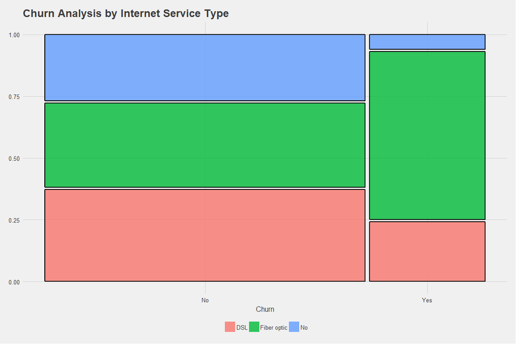

**Observation**: From the above mosaic plot, it can be inferred that, given a customer churns, it is most likely that the customer used **Fiber Optic** for internet service. This could imply that most of the customers are not satisfied with the quality of internet service provided through fiber optics.

### Relationship between gender of the customers and whether the customer churned or not

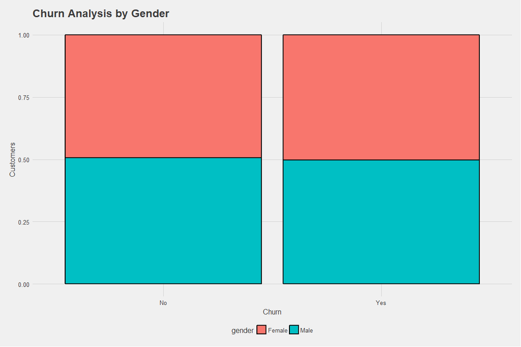

**Observation**: There seems to be no link between customers churning and the gender of the customers.

## MACHINE LEARNING

The final step is to apply *machine learning*, which involves an in-depth data analysis. This step involves building models that predict the propensity of customers to churn, evaluating the results of models, and eventually, choosing the best suitable predictive model to predict customers who may churn.

As the problem aims to predict a binary variable **churn** (Yes/No), a classification model should be applied. Since the model will learn from a training set and predict for a test dataset thereafter, it is a supervised model.

### DATA PREPROCESSING

#### ONE-HOT ENCODING

**Action**: **One hot encoding** is a process by which each factor for each categorical variable is converted into a binary variable, so that it could be provided to ML algorithms to do a better job in prediction. Thus, one-hot encoding is done on the dataset to create a data frame “OHE”, only the necessary variables are kept, and the structure of the dataset is observed:

```
## Classes 'data.table' and 'data.frame':   7043 obs. of  25 variables:
##  $ Gender                 : num  0 1 1 1 0 0 1 0 0 1 ...
##  $ SeniorCitizen          : num  0 0 0 0 0 0 0 0 0 0 ...
##  $ Partner                : num  1 0 0 0 0 0 0 0 1 0 ...
##  $ Dependents             : num  0 0 0 0 0 0 1 0 0 1 ...
##  $ Tenure                 : num  1 34 2 45 2 8 22 10 28 62 ...
##  $ PhoneService           : num  0 1 1 0 1 1 1 0 1 1 ...
##  $ MultipleLines          : num  0 0 0 0 0 1 1 0 1 0 ...
##  $ IS.DSL                 : num  1 1 1 1 0 0 0 1 0 1 ...
##  $ IS.FiberOptic          : num  0 0 0 0 1 1 1 0 1 0 ...
##  $ InternetService        : num  1 1 1 1 1 1 1 1 1 1 ...
##  $ OnlineSecurity         : num  0 1 1 1 0 0 0 1 0 1 ...
##  $ OnlineBackup           : num  1 0 1 0 0 0 1 0 0 1 ...
##  $ DeviceProtection       : num  0 1 0 1 0 1 0 0 1 0 ...
##  $ TechSupport            : num  0 0 0 1 0 0 0 0 1 0 ...
##  $ StreamingTV            : num  0 0 0 0 0 1 1 0 1 0 ...
##  $ StreamingMovies        : num  0 0 0 0 0 1 0 0 1 0 ...
##  $ Contract.Month_to_month: num  1 0 1 0 1 1 1 1 1 0 ...
##  $ Contract.OneYear       : num  0 1 0 1 0 0 0 0 0 1 ...
##  $ PaperlessBilling       : num  1 0 1 0 1 1 1 0 1 0 ...
##  $ CreditCard             : num  0 0 0 0 0 0 1 0 0 0 ...
##  $ ElectronicCheck        : num  1 0 0 0 1 1 0 0 1 0 ...
##  $ MailedCheck            : num  0 1 1 0 0 0 0 1 0 0 ...
##  $ MonthlyCharges         : num  29.9 57 53.9 42.3 70.7 ...
##  $ TotalCharges           : num  29.9 1889.5 108.2 1840.8 151.7 ...
##  $ Churn                  : num  0 0 1 0 1 1 0 0 1 0 ...
##  - attr(*, ".internal.selfref")=<externalptr>
```

How to read the data frame:

- **Gender**: 0 = Female, 1 = Male
- **Senior Citizen**: 0 = No, 1 = Yes
- **Partner**: 0 = No, 1 = Yes
- **Dependents**: 0 = No, 1 = Yes
- **Phone Service**: 0 = No, 1 = Yes
- **MultipleLines** : 0 = No, 1 = Yes
- **Internet Service**: 0 = No, 1 = Yes
- **IS.DSL**: 0 = No, 1 = Yes
- **IS.FiberOptic**: 0 = No, 1 = Yes
- **OnlineBackup** : 0 = No, 1 = Yes
- **OnlineSecurity** : 0 = No, 1 = Yes
- **DeviceProtection** : 0 = No, 1 = Yes
- **TechSupport** : 0 = No, 1 = Yes
- **StreamingTV** : 0 = No, 1 = Yes
- **StreamingMovies** : 0 = No, 1 = Yes
- **Contract.Month_to_month and Contract.OneYear** : Both 0 = “Two Year Contract”
- **PaperlessBilling** : 0 = No, 1 = Yes
- **CreditCard, ElectronicCheck, MailedCheck** : All 0 = “Bank transfer (automatic)”
- **Churn**: 0 = No, 1 = Yes

#### MULTI-COLLINEARITY REMOVAL

Presence of multicollinearity (predictors that are correlated with other predictors in the model, leading to unreliable and unstable estimates of regression coefficients) can degrade the quality of the model. **Thus, the following steps will help to reduce multi-collinearity**.

**Action**: Plotting the correlations among all numerical variables:

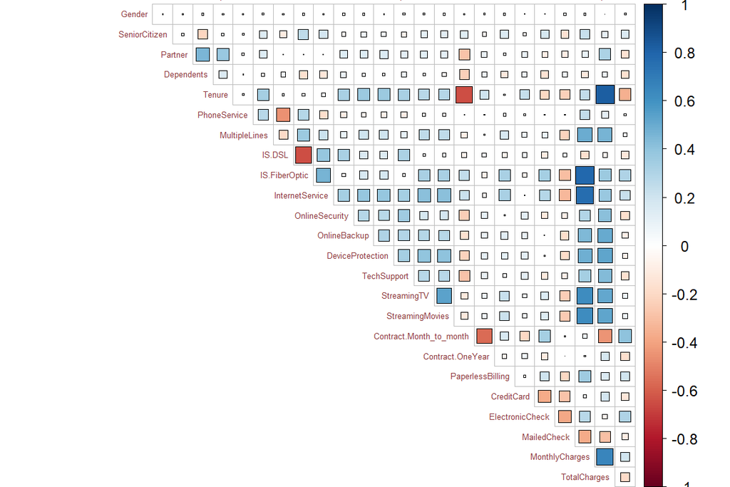

#### DATA SPLITTING

**Action**: Since this is a supervised learning method, the entire dataset will be **split** into a training set (train) and a testing set (test) in a **7:3** ratio, such that the distribution of the *churn* variable remains the same as before, for both of the resulting datasets. The training set will be used to train the model, and the testing set will be used to make predictions, test actual values against predicted values, compare models, and choose the best model on the basis of metrics used for evaluation.

#### SYNTHETIC MINORITY OVERSAMPLING TECHNIQUE

**Action**: As was observed from the exploratory data analysis, the dataset is highly **imbalanced**. Therefore, **Synthetic Minority Over-Sampling Technique (SMOTE)** will be used, to oversample (increase the number of) minority/ under-represented class, and undersample the majority class, so as to strike a balance between the two classes in the training dataset.

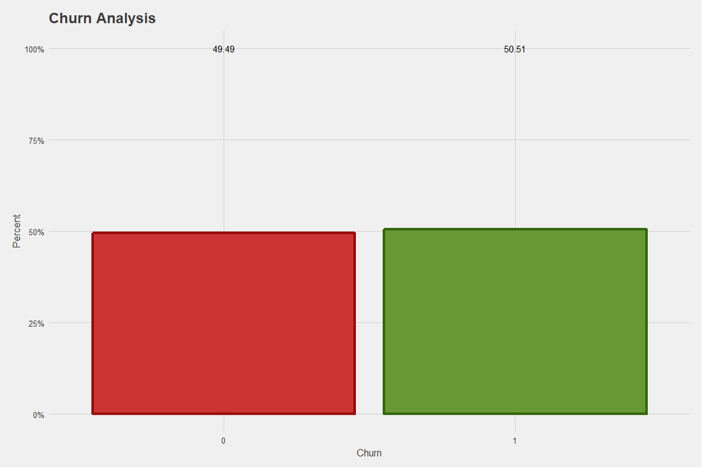

### PREDICTIVE MODELS

Several predictive models will be fit and compared against one another on the basis of appropriate metrics.

#### XGBOOST MODEL

XGBoost is an implementation of gradient boosted decision trees designed for speed and performance. Gradient boosting involves three elements:

- a loss function to be optimized
- a weak learner to make predictions, and
- an additive model to add weak learners to minimize the loss function.

**Action**: Create a XGBoost model, and plot feature importance plot to see the 15 most important features, as per the model:

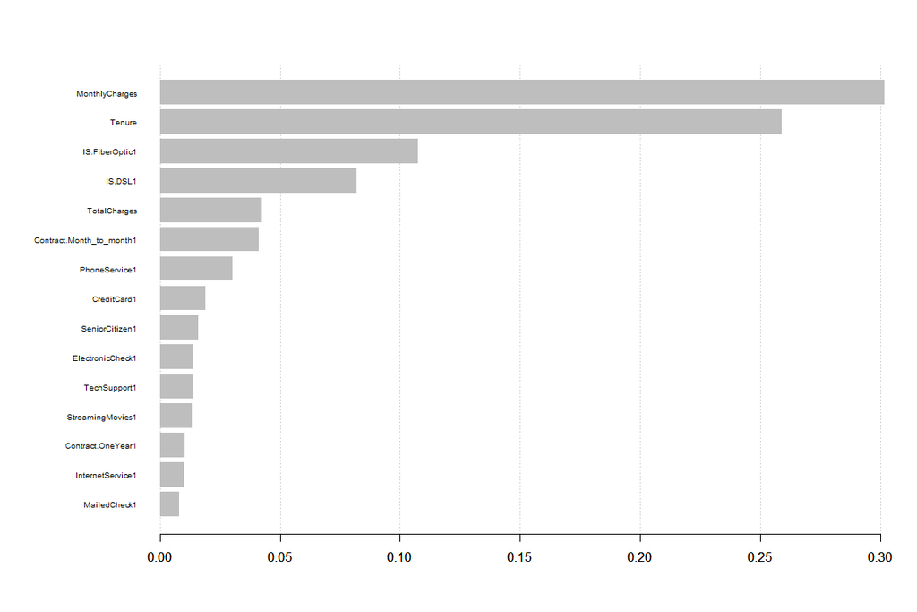

**Action**: Use the XGBoost model for prediction on the test set, store the result in a confusion matrix, and view the resulting confusion matrix:

```
##
##                Will Not Churn Will Churn
##   Didn't Churn           1009        562
##   Churned                 104        437
```

#### RANDOM FOREST

Random forests are ensemble learning methods which create multiple decision trees at the time of training, and outputs the class that is the mode of the classes, for classification models.

#### RANDOM FOREST MODEL 1

**Action**: Fit the random forest model:

```
## Random Forest
##
## 7888 samples
##   24 predictor
##    2 classes: 'X0', 'X1'
##
## Pre-processing: principal component signal extraction (24), centered
##  (24), scaled (24)
## Resampling: Cross-Validated (5 fold, repeated 3 times)
## Summary of sample sizes: 6310, 6310, 6312, 6310, 6310, 6310, ...
## Resampling results across tuning parameters:
##
##   mtry  AUC        Precision  Recall     F
##    2    0.8844030  0.8705618  0.8403349  0.8551109
##   13    0.8296154  0.8528981  0.8551921  0.8540003
##   24    0.8163503  0.8506351  0.8560451  0.8532948
##
## F was used to select the optimal model using the largest value.
## The final value used for the model was mtry = 2.
```

**Action**: Use the Random Forest model for prediction on the test set, store the result in a confusion matrix, and view the resulting confusion matrix:

```
##
##                Will Not Churn Will Churn
##   Didn't Churn           1009        562
##   Churned                 140        401
```